# Pratikum 3 - Regresi Spasial

# 5) Autoregressive Distributed Lag (ARDL)

```r
model.ardl.opt <- ardlBoundOrders(data = data.frame(data_sub), ic = "AIC", formula = Yt ~ Xt)

min_p <- c()
for(i in 1:6){
  min_p[i] <- min(model.ardl.opt$Stat.table[[i]])
}
q_opt <- which(min_p == min(min_p, na.rm = TRUE))
p_opt <- which(model.ardl.opt$Stat.table[[q_opt]] == min(model.ardl.opt$Stat.table[[q_opt]], na.rm = TRUE))

data.frame("Lag_Y_opt(q)" = q_opt, "Lag_X_opt(p)" = p_opt, "AIC" = model.ardl.opt$min.Stat)
```

```
##   Lag_Y_opt.q. Lag_X_opt.p.      AIC
## 1            5           15 124.7089
```

```r
model.ardl <- ardlDlm(formula = Yt ~ Xt, data = train, p = p_opt, q = q_opt)
summary(model.ardl)
```

```
##
## Time series regression with "ts" data:
## Start = 16, End = 57
##
## Call:
## dynlm(formula = as.formula(model.text), data = data)
##
## Residuals:
##      Min       1Q   Median       3Q      Max
## -0.82795 -0.21807 -0.06184  0.19832  0.95292
##
## Coefficients:
##             Estimate Std. Error t value Pr(>|t|)
## (Intercept)  6.39323    8.42066   0.759   0.4566
## Xt.t        -9.79936    3.63098  -2.699   0.0138 *
## Xt.1        12.55109    7.60359   1.651   0.1144
## Xt.2         2.80197    9.55656   0.293   0.7724
## Xt.3        -0.03494   10.20593  -0.003   0.9973
## Xt.4        -8.75652   10.57855  -0.828   0.4176
## Xt.5         7.05101   10.68081   0.660   0.5167
## Xt.6        -4.23104   10.02790  -0.422   0.6776
## Xt.7        -2.27689    9.98750  -0.228   0.8220
## Xt.8        -0.02309    9.52703  -0.002   0.9981
## Xt.9         1.79410    8.66257   0.207   0.8380
## Xt.10        0.55336    7.76096   0.071   0.9439
## Xt.11       -1.03757    6.05781  -0.171   0.8657
## Xt.12        1.60399    3.91378   0.410   0.6863
## Xt.13       -0.35479    2.86667  -0.124   0.9027
## Xt.14       -1.91046    2.85174  -0.670   0.5106
## Xt.15        1.61309    1.52639   1.057   0.3032
## Yt.1         0.57609    0.23251   2.478   0.0223 *
## Yt.2         0.58447    0.26711   2.188   0.0407 *
## Yt.3         0.18559    0.26449   0.702   0.4910
## Yt.4        -0.21285    0.26613  -0.800   0.4332
## Yt.5        -0.33394    0.21453  -1.557   0.1353
## ---
## Signif. codes:  0 '***' 0.001 '**' 0.01 '*' 0.05 '.' 0.1 ' ' 1
##
## Residual standard error: 0.608 on 20 degrees of freedom
## Multiple R-squared:  0.9604, Adjusted R-squared:  0.9187
## F-statistic: 23.07 on 21 and 20 DF,  p-value: 8.9e-10
```

```r
fore.ardl <- forecast(model = model.ardl, x = test$Xt, h = 15)
mape.ardl <- MAPE(fore.ardl$forecasts, test$Yt)
cat("MAPE Model ARDL Optimum:", mape.ardl, "\n")
```

```
## MAPE Model ARDL Optimum: 0.2814882
```

Berdasarkan hasil output model ARDL optimum di atas, variabel X saat ini (Xt) serta variabel Yt1 dan Yt-2 terbukti berpengaruh signifikan terhadap Yt karena memiliki nilai p-value kurang dari 0.05. Selain itu, nilai Multiple R-squared yang sangat tinggi yaitu 0.9604 menunjukkan bahwa sekitar 96.04% variasi dari data berhasil dijelaskan dengan sangat baik oleh model ARDL ini. Dari hasil peramalan, diperoleh nilai MAPE sebesar 0.2815 atau sekitar 28.15%, yang mengindikasikan tingkat akurasi peramalan model ARDL optimum pada data pengujian.

# 6) evaluasi model asumsi (dynlm)

```r
cons_lm1 <- dynlm(Yt ~ Xt + L(Xt), data = train.ts)
summary(cons_lm1)
```

```
##
## Time series regression with "ts" data:
## Start = 2, End = 57
##
## Call:
## dynlm(formula = Yt ~ Xt + L(Xt), data = train.ts)
##
## Residuals:
##     Min      1Q  Median      3Q     Max
## -4.8774 -1.3623 -0.4143  0.9707  4.3977
##
## Coefficients:
##             Estimate Std. Error t value Pr(>|t|)
## (Intercept)   31.354      1.426  21.986  < 2e-16 ***
## Xt            -4.509      1.644  -2.744  0.00828 **
## L(Xt)          2.431      1.161   2.095  0.04098 *
## ---
## Signif. codes:  0 '***' 0.001 '**' 0.01 '*' 0.05 '.' 0.1 ' ' 1
##
## Residual standard error: 2.011 on 53 degrees of freedom
## Multiple R-squared:  0.1505, Adjusted R-squared:  0.1184
## F-statistic: 4.694 on 2 and 53 DF,  p-value: 0.01328
```

Berdasarkan hasil output model dynlm di atas, variabel saat ini (Xt) dan variabel masa lalu (LXt)) terbukti berpengaruh signifikan terhadap Yt karena nilai p-valuenya masing-masing kurang dari 0.05. Meskipun nilai Multiple R-squared sebesar 0.1505 tergolong kecil, model ini tetap sah digunakan untuk melanjutkan pengujian asumsi sisaan (autokorelasi, heteroskedastisitas, dan normalitas).

# 7) uji autokorelasi (durbin-watson)

```r
dwtest(cons_lm1)
```

```
##
##  Durbin-Watson test
##
## data:  cons_lm1
## DW = 0.36907, p-value = 3.414e-16
## alternative hypothesis: true autocorrelation is greater than 0
```

Berdasarkan hasil uji Durbin-Watson di atas, diperoleh nilai DW = 0.36907 dengan p-value sebesar 3.414 10^-16 (jauh di bawah 0.05). Karena p-value kurang dari 0.05, maka H0 ditolak, yang berarti sisaan model ini mengandung masalah autokorelasi positif yang signifikan.

# 8) uji heteroskedastisitas

```r
bptest(cons_lm1)
```

```
##
##  studentized Breusch-Pagan test
##
## data:  cons_lm1
## BP = 8.3784, df = 2, p-value = 0.01516
```

Berdasarkan hasil uji Breusch-Pagan di atas, diperoleh nilai BP = 8.3784 dengan p-value sebesar 0.01516 (kurang dari 0.05). Karena p-value kurang dari taraf nyata 5%, maka H0 ditolak, yang berarti ragam sisaan model ini tidak homogen (terdapat masalah heteroskedastisitas).

# 9) uji normalitas sisaan (shappiro walk)

```r
shapiro.test(residuals(cons_lm1))
```

```
##
##  Shapiro-Wilk normality test
##
## data:  residuals(cons_lm1)
## W = 0.96118, p-value = 0.06876
```

# 10) perbandinga peforma model dan mapenya berapa

```r
akurasi <- matrix(c(mape.koyck, mape.dlm.opt, mape.ardl))
row.names(akurasi) <- c("Koyck", "DLM Optimum", "ARDL Optimum")
colnames(akurasi) <- c("MAPE")
print(akurasi)
```

```
##                   MAPE
## Koyck        0.1394956
## DLM Optimum  0.1748723
## ARDL Optimum 0.2814882
```

Berdasarkan tabel perbandingan akurasi di atas, model Koyck memiliki nilai MAPE terkecil yaitu sebesar 0.1394956 (atau sekitar 13.95%), diikuti oleh model DLM Optimum sebesar 0.1748723 (17.49%), dan terakhir model ARDL Optimum sebesar 0.2814882 (28.15%). Oleh karena itu, model Koyck merupakan model terbaik yang paling akurat dalam melakukan peramalan untuk data kualitas udara ini karena menghasilkan tingkat kesalahan peramalan yang paling rendah di antara ketiga metode.

#b visualisasi

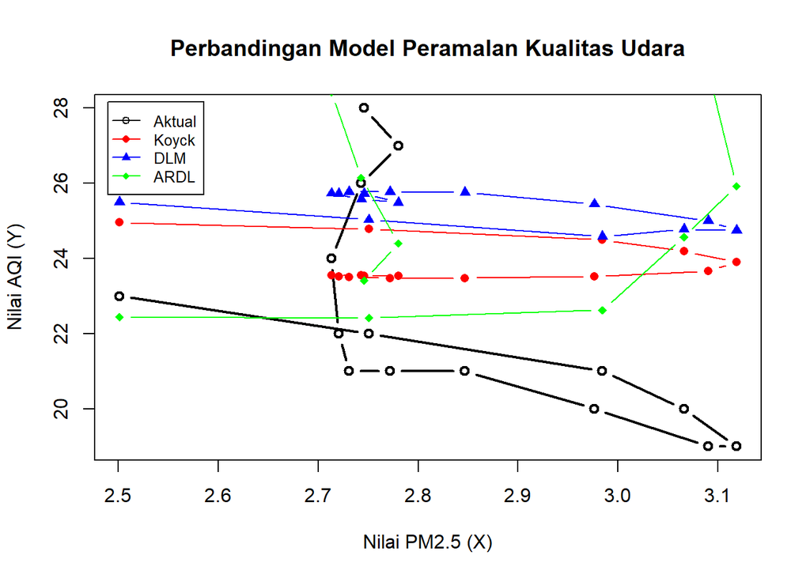

```r
par(mfrow=c(1,1))
plot(test$Xt, test$Yt, type="b", col="black", lwd=2,
     ylab="Nilai AQI (Y)", xlab="Nilai PM2.5 (X)", main="Perbandingan Model Peramalan Kualitas Udara")

lines(test$Xt, fore.koyck$forecasts, col="red", type="b", pch=16)
lines(test$Xt, fore.dlm.opt$forecasts, col="blue", type="b", pch=17)
lines(test$Xt, fore.ardl$forecasts, col="green", type="b", pch=18)

legend("topleft", legend=c("Aktual", "Koyck", "DLM", "ARDL"),
       col=c("black","red","blue","green"), lty=1, pch=c(1,16,17,18), cex=0.8, inset=0.02)
```

Berdasarkan grafik perbandingan model peramalan kualitas udara di atas, garis hitam menunjukkan data aktual, sedangkan garis berwarna merah (Koyck), biru (DLM), dan hijau (ARDL) menunjukkan hasil peramalan dari masing-masing model. Terlihat bahwa pola peramalan dari model Koyck (merah) dan DLM (biru) cenderung lebih stabil dan mendekati kisaran nilai aktual dibandingkan model ARDL. Hal ini selaras dengan nilai MAPE sebelumnya, di mana model Koyck keluar sebagai model yang paling akurat karena jalurnya paling dekat dengan fluktuasi data aktual.